Neuroscience

Research

87

(2014)

8–15

Contents

lists

available

at

ScienceDirect

Neuroscience

Research

[figure not shown]

jo

ur

nal

home

p

age:

www.elsevier.com/locate/neures

[figure not shown]

article

exercise

effects

on

neuroprotection

and

brain

repair

following

A

systematic

review

and

perspective

W.

Austin <sup>a</sup>, Michelle

Ploughman <sup>a</sup><sup>,</sup><sup>∗</sup>, Lindsay

Glynn <sup>b</sup>, Dale

Corbett <sup>c</sup>

ecovery

and

Performance

Laboratory,

Faculty

of

Medicine,

Memorial

University

of

Newfoundland,

St.

John’s,

NL,

Canada

ealth

Sciences

Library,

Faculty

of

Medicine,

Memorial

University

of

Newfoundland,

St.

John’s,

NL,

Canada

anadian

Partnership

for

Stroke

Recovery

and

Department

of

Cellular

and

Molecular

Medicine,

University

of

Ottawa,

Ottawa,

Ontario,

Canada

r t

i c l e

i n f o

icle

history:

ceived

5

March

2014

ceived

in

revised

form

4

May

2014

cepted

24

June

2014

ailable

online

2

July

2014

ywords:

rebrovascular

ercise

ammation

habilitation

ysical

therapy

hemia

a

b

s

t r a

c t

Aerobic

exercise

(AE) enhances

neuroplasticity

and improves

functional

outcome

in animal

models

of

stroke,

however

the optimal

parameters

(days post-stroke,

intensity,

mode,

and duration)

to inﬂuence

brain

repair processes

are not known.

We searched

PubMed,

CINAHL, PsychInfo,

the Cochrane

Library,

and

the

Central

Register

of Controlled

Clinical

Trials,

using predeﬁned

criteria, including all years up to

July

2013

(English

language

only). Clinical

studies

were included

if participants

had experienced

an

ischemic

or

hemorrhagic

stroke. We included

animal

studies

that utilized

any method

of global or focal

ischemic

stroke

or intracerebral

hemorrhage.

Any

intervention

utilizing

AE-based

activity with the intention

of

improving

cardiorespiratory

ﬁtness

was included.

Of the 4250 titles returned,

47 studies

(all in animal

models)

met criteria and measured

the effects of exercise

on brain repair parameters

(lesion

volume,

oxidative

damage,

inﬂammation

and cell death,

neurogenesis,

angiogenesis

and markers

of stress).

Our

synthesized

ﬁndings

show that early-initiated

(24–48 h post-stroke)

moderate

forced

exercise (10 m/min,

5–7

days per week

for about 30 min)

reduced

lesion

volume

and

protected

perilesional

tissue

against

oxidative

damage

and inﬂammation

at least for the short

term (4 weeks).

The applicability

and translation

of

experimental

exercise

paradigms

to clinical trials are discussed.

©

2014 Elsevier

Ireland

Ltd and the Japan Neuroscience

Society.

All rights

reserved.

**ntents**

.

Introduction

9

2.

Search

methodology

. . . . . . . . .

9

3.

Review results. . . . . . . . . . . . . . . . . . . . . . . . . . . . . . . . . . . . . . . . . . . . . . . . . . . . . . . . . . . . . . . . . . . . . . . . . . . . . . . . . . . . . . . . . . . . . . . . . . . . . . . . . . . . . . . . . . . . . . . . . . . . . . . . . . . . . . . . . .

9

3.1.

Aerobic

exercise

effects

on lesion

volume

. . . . . . . . . . . . . . . . . . . . . . . . . . . . . . . . . . . . . . . . . . . . . . . . . . . . . . . . . . . . . . . . . . . . . . . . . . . . . . . . . . . . . . . . . . . . . . . . . . . .

10

3.2.

Aerobic

exercise

effects

on post-stroke

oxidative

damage,

inﬂammation

and cell death . . . . . . . . . . . . . . . . . . . . . . . . . . . . . . .

. . . . . . . . . . . . . . . .

. . . .

11

3.2.1.

Oxidative

damage

. . . . . . . . . . . . . . . . . . . . . . . . . . . . . . . . . . . . . . . . . . . . . . . . . . . . . . . . . . . . . . . . . . . . . . . . . . . . . . . . . . . . . . . . . . . . . . . . . . . . . . . . . . . . . . . . . . .

11

3.2.2.

Inﬂammation

. . . . . . . . . . . . . . . . . . . . . . . . . . . . . . . . . . . . . . . . . . . . . . . . . . . . . . . . . . . . . . . . . . . . . . . . . . . . . . . . . . . . . . . . . . . . . . . . . . . . . . . . . . . . . . . . . . . . . . . .

11

3.2.3.

Cell

death . . . . . . . . . . . . . . . . . . . . . . . . . . . . . . . . . . . . . . . . . . . . . . . . . . . . . . . . . . . . . . . . . . . . . . . . . . . . . . . . . . . . . . . . . . . . . . . . . . . . . . . . . . . . . . . . . . . . . . . . . . . .

11

3.3.

Aerobic

exercise

effects

on post-stroke

neurogenesis.

. . . . . . . . . . . . . . . . . . . . . . . . . . . . . . . . . . . . . . . . . . . . . . . . . . . . . . . . . . . . . . . . . . . . . . . . . . . . . . . .

. . .

. . . .

12

3.4.

Post-stroke

aerobic

exercise-induced

angiogenesis

. . . . . . . . . . . . . . . . . . . . . . . . . . . . . . . . . . . . . . . . . . . . . . . . . . . . . . . . . . . . . . . . . . . . . . . . . . . . . . . . . . . . . . . . . .

12

3.5.

Stress response

to post-stroke

aerobic

exercise

. . . . . . . . . . . . . . . . . . . . . . . . . . . . . . . . . . . . . . . . . . . . . . . . . . . . . . . . . . . . . . . . . . . . . . . . . . . . . . . . . . . . . . . . . . . . . .

12

4.

Discussion

. . . . . . . . . . . . . . . . . . . . . . . . . . . . . . . . . . . . . . . . . . . . . . . . . . . . . . . . . . . . . . . . . . . . . . . . . . . . . . . . . . . . . . . . . . . . . . . . . . . . . . . . . . . . . . . . . . . . . . . . . . . . . . . . . . . . .

. . . . . . .

13

4.1.

Early exercise

post-stroke

. . . . . . . . . . . . . . . . . . . . . . . . . . . . . . . . . . . . . . . . . . . . . . . . . . . . . . . . . . . . . . . . . . . . . . . . . . . . . . . . . . . . . . . . . . . . . . . . . . . . . . . . . . . . . . . . . . . .

13

4.2.

Optimal

exercise

parameters

to promote

brain

recovery

. . . . . . . . . . . . . . . . . . . . . . . . . . . . . . . . . . . . . . . . . . . . . . . . . . . . . . . . . . . . . . . . . . . . . . . . . . . . . . . . . . . .

13

4.3.

Short versus

long term beneﬁts.

. . . . . . . . . . . . . . . . . . . . . . . . . . . . . . . . . . . . . . . . . . . . . . . . . . . . . . . . . . . . . . . . . . . . . . . . . . . . . . . . . . . . . . . . . . . . . . . . . . . . . . . . . . . . . .

13

5.

Conclusions

. . . . . . . . . . . . . . . . . . . . . . . . . . . . . . . . . . . . . . . . . . . . . . . . . . . . . . . . . . . . . . . . . . . . . . . . . . . . . . . . . . . . . . . . . . . . . . . . . . . . . . . . . . . . . . . . . . . . . . . . . . . . . . . . . . . . . . . . . . .

13

Acknowledgements

. . . . . . . . . . . . . . . . . . . . . . . . . . . . . . . . . . . . . . . . . . . . . . . . . . . . . . . . . . . . . . . . . . . . . . . . . . . . . . . . . . . . . . . . . . . . . . . . . . . . . . . . . . . . . . . . . . . . . . . . . . . . . . . . . .

14

References

. . . . . . . . . . . . . . . . . . . . . . . . . . . . . . . . . . . . . . . . . . . . . . . . . . . . . . . . . . . . . . . . . . . . . . . . . . . . . . . . . . . . . . . . . . . . . . . . . . . . . . . . . . . . . . . . . . . . . . . . . . . . . . . . . . . . . . . . . . . .

14

Corresponding

author

at:

Recovery

and

Performance

Laboratory,

L.A.

Miller

Centre,

100

Forest

Road

St.

John’s,

NL,

Canada

A1A

1E5.

Tel.:

+1

709

777

2099;

:

+1

709

777

2082.

E-mail

address:

michelle.ploughman@med.mun.ca

(M.

Ploughman).

p://dx.doi.org/10.1016/j.neures.2014.06.007

68-0102/©

2014

Elsevier

Ireland

Ltd

and

the

Japan

Neuroscience

Society.

All

rights

reserved.

M.W.

Austin

et

al.

/ Neuroscience

Research

87

(2014)

8–15

9

**1.**

**Introduction**

Stroke

is

a

leading

cause

of

disability

among

adults,

with

only

65%

of

survivors

returning

to

full

functional

independence

one

year

after

the

event

(Murray

et

al.,

2012;

Wolfe,

2000).

Approved

treatments

to

reverse

stroke-induced

damage

are

limited,

with

intravenous

ﬁbrinolytic

therapy

and

endovascular

clot

disruption

being

two

of

the

only

treatments

with

proven

beneﬁt

(Ciccone

et

al.,

2013;

Jauch

et

al.,

2013).

Research

examining

the

results

of

rehabil-

itative

efforts

in

physiotherapy,

occupational

therapy,

and

speech

and

language

therapy

are

promising,

but

the

interventions

rarely

lead

to

full

recovery

of

function

(Langhorne

et

al.,

2011).

There

is

an

urgent

need

for

effective

stroke

treatments

supported

by

high

quality

clinical

research.

In

recent

years,

researchers

have

begun

to

investigate

the

effects

of

aerobic

exercise

(AE)

as

a

means

of

enhancing

neuroplastic

change

and

functional

outcomes

after

stroke

(Kreisel

et

al.,

2007;

Mang

et

al.,

2013).

There

is

emerging

evidence

suggesting

that

AE

is

neuroprotective,

preventing

age-related

brain

atrophy

and

enhanc-

ing

performance

in

healthy

populations

(Cotman

and

Berchtold,

2002;

Kramer

et

al.,

2006)

and

in

populations

with

neurode-

generative

diseases

(Ahlskog

et

al.,

2011),

however

the

optimal

parameters

(days

post-stroke,

intensity,

mode,

duration)

to

inﬂu-

ence

brain

repair

processes

are

not

known

(Schmidt

et

al.,

2013).

Animal

studies

suggest

that

early

intervention

is

more

effective

than

delayed

intervention

(Biernaskie

et

al.,

2004)

however

inten-

sive

treatments

given

too

early

(e.g.

1–3

days

post-stroke)

may

exacerbate

injury

(Risedal

et

al.,

1999).

Accordingly,

clinical

guide-

lines

for

stroke

now

suggest

that

treatment

interventions

begin

as

early

as

possible,

although

how

intense

or

how

early

the

interven-

tion

should

be

has

not

yet

been

established

(Jauch

et

al.,

2013).

Large

scale

trials

of

very

early

mobilization

and

exercise

after

stroke,

such

as

the

AVERT

trial,

are

underway

(Bernhardt

et

al.,

2006),

and

pre-

liminary

ﬁndings

suggest

that

mobilization

within

24

h

of

stroke

is

safe

(Bernhardt

et

al.,

2008),

is

associated

with

better

functional

recovery

(Cumming

et

al.,

2011),

and

is

cost-effective

(Tay-Teo

et

al.,

2008).

That

said,

early

mobilization

is

not

the

same

as

AE

and

others

have

reported

that

mobilization

beginning

within

24

h

after

stroke

is

associated

with

poorer

outcomes,

increased

depend-

ency,

and

higher

rates

of

death

when

compared

to

mobilization

between

24

and

48

h

(Sundseth

et

al.,

2012).

If

AE

were

to

be

imple-

mented

as

part

of

early

post-stroke

care,

clinicians

would

have

to

be

assured

(through

both

animal

models

and

randomized

controlled

trials)

that

AE

could

safely

be

applied

(Bernhardt

et

al.,

2007).

In

clinical

trials,

AE

interventions

have

taken

place

during

the

sub-

acute

and

chronic

stages

of

stroke.

Literature

reviews

(Brogardh

and

Lexell,

2012)

and

meta-analysis

(Stoller

et

al.,

2012) report

that

AE

in

sub-acute

and

chronic

stroke

leads

to

improved

gait

and

aerobic

capacity;

however,

the

evidence

that

AE

inﬂuences

brain

repair,

neuroplasticity

and

cognitive

function

is

less

compelling

(Stoller

et

al.,

this

systematic

review

in

order

to

consolidate

potentially

important

ﬁndings

of

post-stroke

AE

in

animal

mod-

els

and

clinical

trials;

speciﬁcally,

we

aimed

to

ask,

(1)

at

what

point

after

stroke

can

AE

be

safely

implemented

to

gain

maximum

beneﬁt?;

(2)

What

is

the

relationship,

if

any,

between

post-stroke

AE

and

brain

repair

processes?

and

(3)

What

can

be

gleaned

from

preclinical

evidence

to

inform

future

clinical

trials?

**2.**

**Search**

**methodology**

We

aimed

to

identify

all

human

and

animal

studies

relating

to

stroke,

aerobic

exercise,

cognition

and

markers

of

behavioral

recov-

ery

and

neuroplasticity.

Excluding

non-English

titles

and

following

PRISMA

guidelines

(Liberati

et

al.,

2009),

we

searched

PubMed,

**Table**

**1**

Search

keywords.

Population

Intervention

Outcome

Stroke

hemorrhage

Exercise

Executive

function

Ischemia

Motor

activity

Cognition

Infarct

Exercise

Plasticity

Cerebral

artery

occlusion

Physical

activity

Recovery

Vascular

accident

Aerobic

Memory

Human

Physical

conditioning

Brain-derived

neurotrophic

factor

Animal

Treadmill

Mental

process

Mice

Running

Performance

Rat

Fitness

Neurotrophic

CINAHL,

PsychInfo,

the

Cochrane

Library,

and

the

Central

Regis-

ter

of

Controlled

Clinical

Trials,

including

all

years

up

to

July

13,

2013.

Based

on

previous

research,

we created

the

keyword

search

list

(Table

1)

and

search

strategies

were

designed

and

performed

by

a

librarian

specializing

in

systematic

reviews

(LG)

with

input

on

keyword

selection

provided

from

two

other

authors

(MA,

MP).

Reference

lists

of

included

articles

were

hand-searched

for

other

studies

with

potential

relevance.

Human

studies

were

included

if

participants

were

over

the

age

of

18

and

had

experienced

an

ischemic

or

hemorrhagic

stroke.

No

criteria

were

set

for

time

since

stroke

occurrence.

We included

animal

studies

that

utilized

any

method

of

global

(two

vessel

occlusion)

or

focal

ischemic

stroke

(transient

or

permanent

middle

cerebral

artery

occlusion,

photothrombosis,

endothelin-1-induced

occlusion)

or

intracerebral

hemorrhage

(collagenase

injection).

In

human

studies,

any

intervention

utilizing

AE-based

activity

(ergometry,

swimming,

treadmill

walking/running)

with

the

inten-

tion

of

improving

cardiorespiratory

ﬁtness

was

accepted

for

this

review.

Exercise

must

have

been

implemented

for

more

than

2

min,

following

stroke,

to

meet

the

threshold

for

aerobic

metabolism

(Medbo

et

al.,

1988) and

at

least

one

component

of

AE

ﬁtness

(perceived

exertion,

heart

rate,

etc.)

must

have

been

measured.

Activities

undertaken

as

task-speciﬁc

training

(i.e.

gait

practice

to

improve

walking

speed)

were

not

included.

In

animal

stud-

ies,

post-stroke

AE

included

both

voluntary

exercise

(VE),

which

is

placement

in

a

cage

with

access

to

a

voluntary

running

wheel,

and

forced

exercise

(FE),

which

included

forced

motorized

tread-

mill

running,

placement

in

a

motorized

running

wheel,

swimming,

or

placement

on

a

rotating

rod.

Title

results

across

search

databases

were

merged

into

a sin-

gle

database

and

inclusion

status

independently

evaluated

by

two

authors

(MA,

MP).

If

the

authors

disagreed,

the

title

was

included.

Abstracts

of

accepted

titles

were

evaluated

in

the

same

man-

ner

resulting

in

a

ﬁnal

ﬁle

containing

accepted

manuscripts.

We

extracted

and

categorized

the

data

from

the

included

studies

and

described

methods

and

data

quality

using

an

article

summary

form.

Consistency

of

ﬁndings

and

methodology

across

laboratories

and

stroke

models

was

noted.

In

order

to

compare

results

across

stud-

ies,

we

recalculated

lesion

size

by

expressing

average

lesion

size

in

exercising

animals

as

a

percentage

of

the

volume

of

the

average

lesion

size

in

sedentary

controls

at

the

ﬁrst

point

of

measurement

after

stroke.

**3.**

**Review**

**results**

Of

the

4250

titles

returned

in

the

initial

search,

a

total

of

were

identiﬁed

for

further

review

(Fig.

1).

Of

the

ﬁnal

72

manuscripts,

47

studies

involved

the

effects

of

exercise

on

brain

repair

parameters

(lesion

volume,

oxidative

damage,

inﬂammation,

cell

death,

neurogenesis,

angiogenesis

and

stress;

Table

2)

so

were

included

in

this

review.

The

effects

of

AE

on

other

outcomes

such

M.W.

Austin

et

al.

/ Neuroscience

Research

87

(2014)

8–15

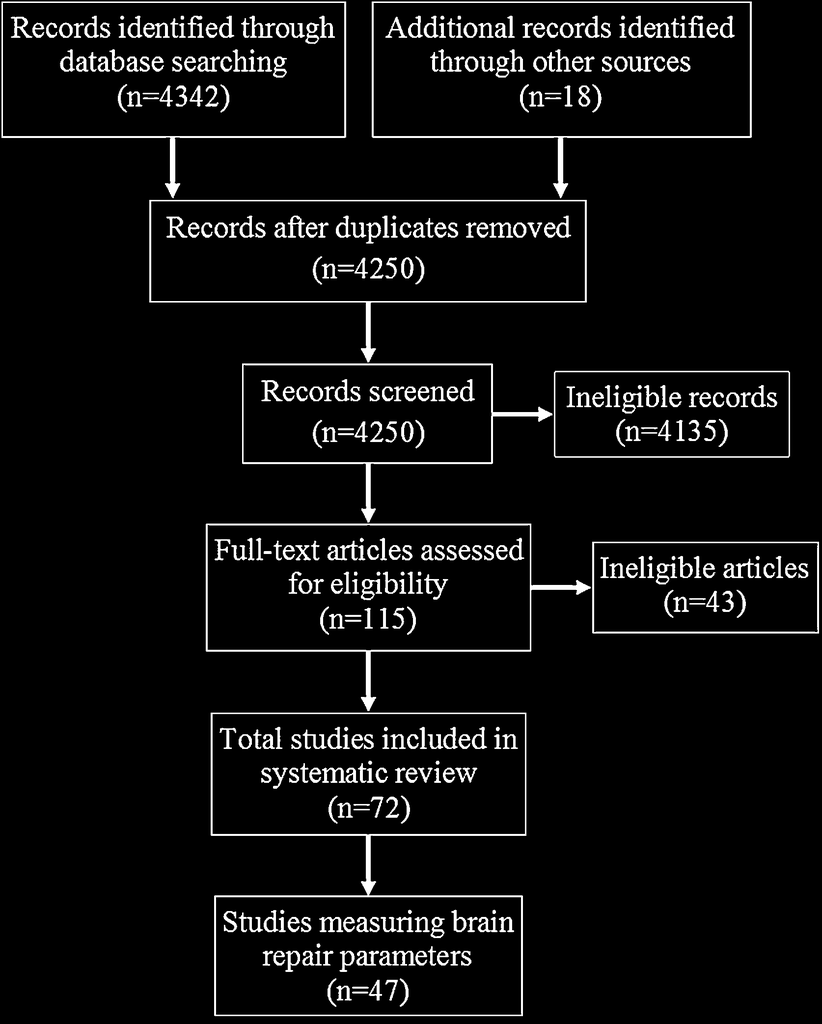

**Fig.**

**1.**

PRISMA

ﬂowchart

of

search

strategy.

behavior

and

neurotrophins

were

excluded.

No

human

studies

inclusion/exclusion

criteria.

Thirty-six

of

47

studies

employed

model

of

injury

to

the

middle

cerebral

artery

territory

in

young

ult

male

rats

while

two

used

mice

(Gertz

et

al.,

2006;

Luo

et

al.,

07).

Only

two

studies

examined

the

effects

of

AE

in

old

animals

ing

et

al.,

2003;

Maldonado

et

al.,

2008).

Two

studies

used

female

**ble**

**2**

luded

studies.

Outcome

Reference

esion

volume

(n

=

33)

Chang

et

al.

(2011), Dahlqvist

et

al.

(2003),

Ding

et

al.

(2003,

2004),

Gertz

et

al.

(2006), Hu

et

al.

(2010),

Johansson

and

Ohlsson

(1996),

Komitova

et

al.

(2005), Lee

et

al.

(2003a,

2005,

2008,

2009), Luo

et

al.

(2007), Ma

et

al.

(2013a,b),

Maldonado

et

al.

(2008), Marin

et

al.

(2003),

Matsuda

et

al.

(2011), Quirie

et

al.

(2012),Risedal

et

al.

(2002), Sakakima

et

al.

(2012),Shimada

et

al.

(2013), Wang

et

al.

(2005),

Yang

et

al.

(2012,

2003a,b),

Zhang

et

al.

(2012a,b,c,

2013a,b,c)

and

Zheng

et

al.

(2011)

Oxidative

damage

(n

=

2),

inﬂammation

(n

=

3)

&

cell

death

(n

=

11)

Cechetti

et

al.

(2012), Lee

et

al.

(2003a,b,

2005),

Matsuda

et

al.

(2011), Mizutani

et

al.

(2011),

Sakakima

et

al.

(2012), Sim

et

al.

(2004,

2005),

Song

et

al.

(2012)

and

Zhang

et

al.

(2012a,b,d)

Neurogenesis

(n

= 14)

Briones

et

al.

(2004,

2005), Jin

et

al.

(2010),

Komitova

et

al.

(2005), Lee

et

al.

(2003b,

2005,

2008),Luo

et

al.

(2007), Shimada

et

al.

(2013),

Sim

et

al.

(2004), Song

et

al.

(2012), Yagita

et

al.

(2006)

and

Zhang

et

al.

(2013a,c)

Angiogenesis

(n

=

6)

Hu

et

al.

(2010), Ma et

al.

(2013b), Matsuda

et

al.

(2011), Sakakima

et

al.

(2012), Yang

et

al.

(2012)

and

Zheng

et

al.

(2011)

tress

(n

= 6)

Dahlqvist

et

al.

(2003), Ke

et

al.

(2011),

Mizutani

et

al.

(2011), Ploughman

et

al.

(2005,

2007)

and

Risedal

et

al.

(2002)

animals

but

did

not

control

for

estrous

cycle

(Maldonado

et

al.,

2008;

Wang

et

al.,

2005).

Seven

studies

examined

global

ischemia

in

rats

(Briones

et

al.,

2004,

2005;

Cechetti

et

al.,

2012;

Yagita

et

al.,

2006)

or

gerbils

(Lee

et

al.,

2003b;

Sim

et

al.,

2004,

2005) and

three

studied

exercise

in

a

hemorrhagic

model

of

stroke

(Jin

et

al.,

2010;

Lee

et

al.,

2003a,

2005).

3.1.

Aerobic

exercise

effects

on

lesion

volume

Thirty-three

animal

studies

investigated

the

effects

of

AE

after

stroke

on

lesion

volume.

Up

to

28

days

following

stroke,

gradual

shrinking

of

the

lesion

is

observed,

even

in

sedentary

control

ani-

mals

(Matsuda

et

al.,

2011;

Shimada

et

al.,

2013;

Yang

et

al.,

2003b;

Zhang

et

al.,

2013a).

No

studies

reported

an

increase

in

lesion

vol-

ume

following

aerobic

activity,

even

when

exercise

was

initiated

as

early

as

one

day

after

stroke.

studies

reported

insigniﬁcant

effects

of

AE

on

lesion

volume

after

stroke

when

compared

to

sedentary

controls.

The

study

methodologies

had

some

common

features:

(1)

exercise

was

initiated

three

or

more

days

post-stroke

(Ding

et

al.,

2003,

2004;

Lee

et

al.,

2005,

2008;

Ma et

al.,

2013a,b;

Quirie

et

al.,

2012;

Sakakima

et

al.,

2012);

(2)

the

mode

of

exercise

was

VE

rather

than

FE

(Dahlqvist

et

al.,

2003;

Johansson

and

Ohlsson,

1996;

Komitova

et

al.,

2005;

Luo

et

al.,

2007;

Marin

et

al.,

2003),

or

the

meth-

ods

included

both

delayed

intervention

and

VE

(Gertz

et

al.,

2006;

Maldonado

et

al.,

2008;

Risedal

et

al.,

2002).

Forced

exercise

paradigms,

whether

treadmill

FE

(Chang

et

al.,

2011;

Lee

et

al.,

2005,

2009;

Matsuda

et

al.,

2011;

Shimada

et

al.,

2013;

Wang

et

al.,

2005;

Yang

et

al.,

2012,

2003a,b;

Zhang

et

al.,

2012a,b,c,

2013a,b,c;

Zheng

et

al.,

2011) or

running

wheel

FE

(Hu

et

al.,

2010) reduced

lesion

volumes

compared

to

sedentary

controls.

However,

daily

20

min

FE

in

the

form

of

rota-rod

training

(4.8

m/min)

beginning

three

days

after

stroke

for

two

weeks

did

not

result

in

signiﬁcant

differences

(Sakakima

et

al.,

2012).

All

treadmill

training

sessions

lasted

20–30

min,

and

took

place

5–7

days

per

week.

Despite

differences

in

stroke

models,

ﬁndings

were

consistent;

two

studies

examined

hemorrhagic

stroke

(Lee

et

al.,

2003a,

2005),

the

remainder

employed

models

of

focal

ischemia

of

various

of

the

effects

of

FE

on

lesion

volume

revealed

differential

effects

of

post-stroke

exercise

onset,

duration

of

exer-

cise,

and

exercise

intensity.

All

FE

protocols

that

began

very

early

(24

h)

after

stroke

resulted

in

signiﬁcant

reductions

in

volume

(Chang

et

al.,

2011;

Hu

et

al.,

2010;

Lee

et

al.,

2005,

2009;

Matsuda

et

al.,

2011;

Wang

et

al.,

2005;

Yang

et

al.,

2012,

2003a,b;

Zhang

et

al.,

2012a,b,c;

Zheng

et

al.,

2011).

Two

studies

speciﬁcally

com-

pared

timing

of

FE

initiation

after

stroke

and

found

that

early

exercise

(commencing

24

h

post-stroke)

reduced

lesion

volumes

signiﬁcantly

more

than

late

exercise

(3–7

days

post-stroke)

(Lee

et

al.,

2005;

Yang

et

al.,

2003a).

Volume

of

the

lesion

reduces

over

time

even

in

sedentary

stroke

control

animals

but

FE

appears

to

augment

this

effect

by

protec-

ting

tissue

that

would

ordinarily

die

(Fig.

2).

Consistent

ﬁndings

from

various

studies

in

different

laboratories

indicate

that

longer

FE

exercise

durations

(14–28

days)

resulted

in

greater

tissue

pro-

tection

than

FE

for

shorter

periods

(7

days)

(Hu

et

al.,

2010;

Lee

et

al.,

2009;

Matsuda

et

al.,

2011;

Wang

et

al.,

2005;

Yang

et

al.,

2003b;

Zhang

et

al.,

2012a).

In

one

study

(Wang

et

al.,

2005),

comparing

the

effect

of

age

(3–4

month

old

rodents

versus

22–24

months)

on

the

timing

of

FE-induced

beneﬁts

showed

that

younger

animals

gained

beneﬁt

earlier

(i.e.

in

the

ﬁrst

7

days)

compared

to

the

older

animals.

In

terms

of

differential

effects

of

exercise

intensity

(FE)

begin-

ning

24

h

after

stroke,

lower

intensity

exercise

(30–40%

of

rodents’

maximum

running

speed

or

<10

m/min

on

a

treadmill)

(Chang

et

al.,

2011;

Lee

et

al.,

2009;

Yang

et

al.,

2012;

Zhang

et

al.,

2012a,

M.W.

Austin

et

al.

/ Neuroscience

Research

87

(2014)

8–15

11

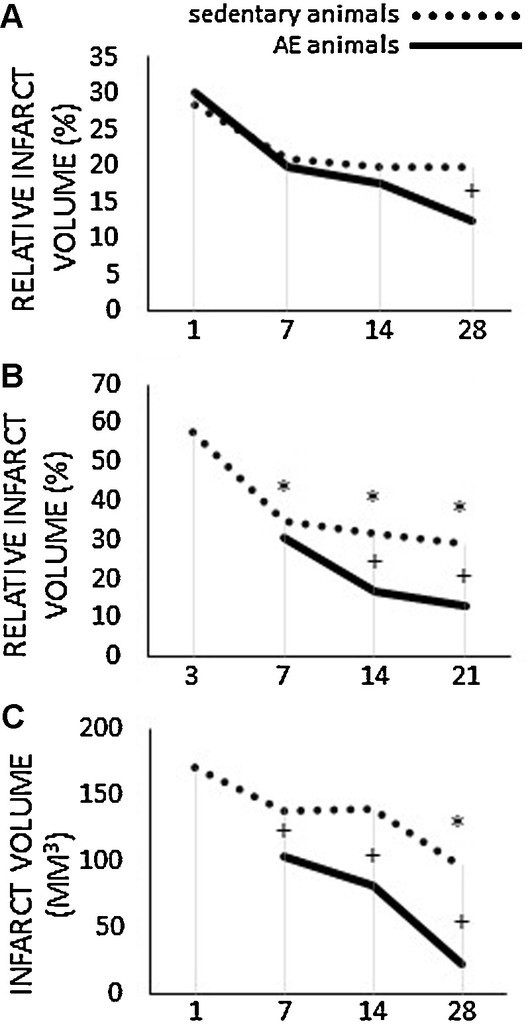

**Fig.**

**2.**

Data

from

the

three

studies,

measuring

lesion

size

after

FE

at

similar

time

points

post-stroke

are

recalculated

(A

and

B

only)

as

a

percentage

of

sedentary

stroke

control

animals.

A,

Matsuda

et

al.

(2011); B,

Zhang

et

al.

(2013c); C,

Yang

et

al.

(2003b).*Signiﬁcantly

less

than

baseline

measurement

(p

<

0.01); <sup>+</sup>Signiﬁcantly

less

than

control

group

(p

<

0.05).

2013a) tended

to

reduce

lesion

volume

more

than

moderate

or

vigorous

intensities

whether

the

duration

was

7

days

(25–58%

of

the

volume

of

sedentary

control

lesions)

or

14

days

(22–58%).

The

exception

to

this

trend

were

the

results

of

three

studies

(Yang

et

al.,

2012;

Zhang

et

al.,

2012a;

Zheng

et

al.,

2011)

that

reported

greater

lesion

reduction

(i.e.

greater

neuroprotective

effect),

ranging

from

21%

to

32%

of

volume

of

sedentary

controls,

following

moder-

ate

intensity

exercise

(12–20

m/min).

All

of

the

rodents

in

these

studies

were

preconditioned

with

three

days

of

treadmill

training

prior

to

receiving

stroke,

which

in

and

of

itself

may

have

provided

some

neuroprotective

effect.

Only

Yang

et

al.

(2012)

reported

that

moderate

intensity

exercise

was

more

effective

than

low

inten-

sity

exercise;

this

study

was

unique

in

that

rats

exercised

for

ﬁve

days

per

week

as

opposed

to

seven

days,

therefore

it

is

pos-

sible

that

less

frequent

but

higher

intensity

exercise

may

be

of

beneﬁt.

In

summary,

in

animal

models

of

stroke,

daily

FE,

but

not

VE,

initiated

very

early

post-stroke

and

continuing

beyond

14

days

reduced

lesion

size

by

sparing

vulnerable

tissue.

Furthermore,

in

terms

of

optimal

exercise

parameters,

in

most

studies

using

naïve

animals,

low

to

moderate

running

speeds

for

greater

than

2

weeks

post-stroke

appeared

to

be

more

beneﬁcial

than

shorter

duration

or

more

intensive

running

protocols.

3.2.

Aerobic

exercise

effects

on

post-stroke

oxidative

damage,

inﬂammation

and

cell

death

Following

ischemic

stroke,

excitotoxicity

leads

to

inﬂammation

and

oxidative

stress

in

affected

tissue,

resulting

in

blood

brain

bar-

rier

dysfunction,

microvascular

injury,

and

cell

death,

that

in

turn

leads

to

cerebral

damage

(Lakhan

et

al.,

2009).

An

increasing

body

of

evidence

suggests

that

progression

of

ischemic

stroke

in

the

acute

phase

is

related

to

inﬂammation;

however,

later

inﬂamma-

tory

responses

may

contribute

to

repair

and

recovery

(Wang

et

al.,

2007).

Thirteen

studies

included

in

this

review

investigated

the

effects

of

AE

on

oxidative

damage,

inﬂammation,

and/or

cell

death.

3.2.1.

Oxidative

damage

Two

studies

investigated

the

effects

of

long

term,

moderate

intensity

FE

on

oxidative

damage

in

models

of

global

(Cechetti

et

al.,

2012)

and

focal

(Song

et

al.,

2012) ischemia.

These

stud-

ies

suggest

that

exercise

increases

genes

and

proteins

associated

with

protection

from

oxidative

damage

and

does

not

signiﬁcantly

elevate

free

radical

levels.

In

the

global

ischemia

study,

rodents

exercised

for

12

weeks,

three

times

per

week,

gradually

progres-

sing

from

12

to

over

12

weeks,

resulted

in

favorable

regulation

of

thiobarbituric

acid

reactive

substances,

a

marker

of

oxidative

lipid

damage,

within

the

hippocampus

(but

not

the

cor-

tex

or

striatum).

Superoxide

dismutase,

an

antioxidant

defence

enzyme,

as

well

as

free

radical

levels

were

not

signiﬁcantly

affected

by

exercise

(Cechetti

et

al.,

2012).

Similarly,

after

focal

ischemia

of

the

left

parietal

lobe,

forced

swimming

exercise,

initiated

24

h

post-stroke

(20

min/day,

5

days/week),

suppressed

oxidative

lipid

damage

(malondialdehyde)

and

increased

superoxide

dismutase

activity

in

the

hippocampus

of

the

ischemic

hemisphere

(Song

et

al.,

2012).

3.2.2.

Inﬂammation

Days

after

the

initial

ischemic

event,

delayed

injury

and

sec-

ondary

inﬂammation

occurs,

especially

in

regions

adjacent

to

the

ischemic

lesion

(Heiss,

2012).

The

three

studies

included

in

this

review

report

a

reduction

in

inﬂammation

in

response

to

AE

after

stroke

(Mizutani

et

al.,

2011;

Sakakima

et

al.,

2012;

Zhang

et

al.,

2012d).

Two

weeks

of

moderate

intensity

FE

initiated

24

h

after

stroke

in

rodents

signiﬁcantly

inhibited

microglia-mediated

release

of

pro-inﬂammatory

cytokines

in

perilesional

cortex

and

striatum

when

assessed

after

3,

5,

and

7

days

of

exercise.

Further-

more,

this

protocol

also

signiﬁcantly

reduced

mRNA

expression

of

ICAM-1,

which

contributes

to

neuro-inﬂammation

caused

by

ischemia

at

the

same

time

points

(Zhang

et

al.,

2012d).

Two

studies

examined

how

delayed

exercise,

beginning

in

the

sub-acute

phase

of

stroke,

might

affect

more

delayed

glial

responses.

Daily

20-min

rota-rod

training

(4.8

m/min),

for

two

weeks

beginning

3

days

after

a

focal

lesion

signiﬁcantly

decreased

GFAP

(a

marker

of

astroglial

cell

activity

associated

with

scarring)

in

areas

sur-

rounding

the

lesion

(Sakakima

et

al.,

2012);

however,

21

days

of

mild-to-moderate

FE

signiﬁcantly

increased

GFAP

in

the

cortex

(Mizutani

et

al.,

2011).

3.2.3.

Cell

necrosis

and

a

cascade

of

apoptotic

(pro-

grammed

cell

death)

events

induced

by

oxygen

free

radicals,

DNA

damage,

ionic

imbalance,

and

protease

activation

in

the

affected

tissue

(Doyle

et

al.,

2008).

Eleven

studies

investigated

the

effects

of

AE

after

stroke

on

apoptosis

assessed

5–28

days

after

stroke

(Lee

et

al.,

2003a,b,

2005;

Matsuda

et

al.,

2011;

Mizutani

et

al.,

2011;

Sakakima

et

al.,

2012;

Sim

et

al.,

2004,

2005;

Zhang

et

al.,

2012a,

2013b).

Most

studies

investigating

exercise-induced

effects

on

apopto-

sis

after

stroke

used

FE

paradigms.

Low

to

moderate

intensity

(<%60

M.W.

Austin

et

al.

/ Neuroscience

Research

87

(2014)

8–15

aximum

running

intensity

or

8–13

m/min,

20–30

min/day)

FE

ercise

initiated

24–48

h

after

stroke

reduced

DNA

fragmentation

ee

et

al.,

2005;

Zhang

et

al.,

2012a,

2013c)

and

caspase-3

(Lee

et

al.,

03a,b;

Matsuda

et

al.,

2011;

Sim

et

al.,

2004,

2005;

Zhang

et

al.,

13b),

all

of

which

are

markers

and/or

facilitators

of

apoptotic

cell

ath.

This

regimen

also

increased

bcl-2

(Zhang

et

al.,

2013b)

and

dkine

(Matsuda

et

al.,

2011);

known

inhibitors

of

apoptosis.

One

of

the

important

considerations

in

applying

exercise

post-

roke

is

identifying

the

optimal

time

window

for

intervention.

e

studies

described

above

consistently

show

that

exercise

is

pro-

ctive

when

initiated

1–2

days

post

stroke,

at

least

for

the

short

rm

(<4

weeks

post-stroke).

One

study,

exploring

the

effects

of

layed

(3

days)

forced

rota-rod

training

(4.8

m/min,

20

min/day,

r

14

days)

also

showed

reduced

DNA

fragmentation

and

caspase-

expression

in

the

perilesional

region

(Sakakima

et

al.,

2012).

nly

one

study

examined

exercise

initiated

immediately

follow-

g

stroke

(3

h)

and

found

that

the

protective

effect

adjacent

to

e

hemorrhagic

core

was

abolished

(when

tested

at

11

days)

th

this

very

early

intervention

(Lee

et

al.,

2005).

In

contrast

the

extensive

research

in

FE,

only

one

study

investigated

the

fects

of

VE

on

apoptotic

markers.

Mizutani

et

al.

(2011)

reported

at

two

weeks

of

12

h

daily

running

wheel

exposure

beginning

h

after

middle

cerebral

artery

occlusion

signiﬁcantly

reduced

o-apoptotic

markers

in

the

ipsilesional

cortex

seven

days

after

farction.

In

summary,

this

body

of

evidence

suggests

that

in

animal

odels,

moderate

intensity

FE

beginning

1–2

days

after

stroke

is

otective

against

oxidative

damage

and

ameliorates

inﬂammatory

ocesses

early

after

stroke.

Long

term

protection

beyond

28

days

s

not

been

studied.

Exercise

beginning

less

than

24

h

follow-

g

stroke

may

not

be

as

beneﬁcial

in

preventing

apoptosis.

The

le

of

exercise

in

glial

scar

formation

in

the

affected

area

is

less

ear.

3.

Aerobic

exercise

effects

on

post-stroke

neurogenesis

In

adult

mammals,

adult

neurogenesis

occurs

in

the

subven-

cular

zone

and

the

subgranular

zone

of

the

dentate

gyrus

of

the

ppocampus

(Wiltrout

et

al.,

2007).

Following

stroke,

these

new-

rn

cells

tend

to

migrate

toward

damaged

brain

tissue

(Wiltrout

al.,

2007).

In

animals,

inhibition

of

neurogenesis

is

associated

th

decreases

in

long

term

recovery

and

increases

in

lesion

volume

ter

a

focal

lesion

(Sun

et

al.,

2012).

Fourteen

studies

examined

neurogenesis

post-stroke,

follow-

g

both

VE

(Jin

et

al.,

2010;

Komitova

et

al.,

2005;

Luo

et

al.,

07;

Yagita

et

al.,

2006);

and

FE

(Briones

et

al.,

2004,

2005;

e

et

al.,

2003b,

2005,

2008;

Shimada

et

al.,

2013;

Sim

et

al.,

04;

Song

et

al.,

2012;

Zhang

et

al.,

2013a,c).

This

synthesized

ta

suggests

that

VE

has

differential

effects

depending

on

exer-

e

duration

and

housing

conditions.

Regardless

of

the

model

of

roke

or

timing

of

AE

initiation,

long

term

VE

(3–6

weeks)

pro-

ded

rats

are

not

housed

in

isolation

for

long

periods

of

time

omitova

et

al.,

2005;

Yagita

et

al.,

2006),

enhanced

neurogen-

is

after

stroke

(Jin

et

al.,

2010;

Luo

et

al.,

2007)

and

may

promote

gration

of

surviving

newborn

cells

to

the

lesion

site

(Jin

et

al.,

10).

FE

appears

to

have

beneﬁcial

effects

on

neurogenesis

as

well.

ort-term

FE

(8–14

days)

is

associated

with

reduced

neurogene-

but

also

decreased

apoptosis

(Lee

et

al.,

2003b;

Sim

et

al.,

2004;

ang

et

al.,

2013a)

suggesting

a

possible

rescue

of

neuronal

cells.

nger

term

FE

(20–40

min/day)

for

2–4

weeks

seems

to

consis-

ntly

increase

neurogenesis

(Lee

et

al.,

2008;

Shimada

et

al.,

2013;

ng

et

al.,

2012;

Zhang

et

al.,

2013c)

except

when

exercise

is

per-

rmed

for

only

5

min

a

day

at

low

intensities

(Briones

et

al.,

2004,

05).

3.4.

Post-stroke

aerobic

exercise-induced

angiogenesis

Induction

of

angiogenesis,

the

growth

of

new

blood

vessels,

not

only

increases

blood

ﬂow

to

the

area

affected

by

stroke,

but

also

stimulates

recovery

mechanisms

such

as

neurogenesis,

synaptoge-

nesis,

and

contributes

to

synaptic

and

neuronal

plasticity

(Ergul

et

al.,

2012;

Schmidt

et

al.,

2013).

Six

studies

investigated

the

effects

of

AE

on

angiogenesis

after

stroke,

all

of

which

employed

FE

paradigms

(Hu

et

al.,

2010;

Ma et

al.,

2013b;

Matsuda

et

al.,

2011;

Sakakima

et

al.,

2012;

Yang

et

al.,

2012;

Zheng

et

al.,

2011).

Two

weeks

of

moderate

to

high

intensity

FE

beginning

1–3

days

following

focal

ischemia

resulted

in

increased

expression

of

a

vari-

ety

of

angiogenesis-promoting

proteins,

including

angiopoietein-1

(Zheng

et

al.,

2011),

CD-31

cells

(Hu

et

al.,

2010;

Matsuda

et

al.,

2011;

Sakakima

et

al.,

2012;

Yang

et

al.,

2012),

MMP2

and

VEGF

mRNA

(Ma et

al.,

2013b)

and

TIE-2

receptors

(Zheng

et

al.,

2011)

in

the

cortex

surrounding

the

lesion

(Hu

et

al.,

2010;

Ma

et

al.,

2013b;

Matsuda

et

al.,

2011;

Sakakima

et

al.,

2012) and

striatum

(Yang

et

al.,

2012).

The

same

beneﬁts

are

not

seen

in

lower

intensity

exercise

(8

m/min)

(Yang

et

al.,

2012)

or

when

training

continues

beyond

two

weeks

post-ischemia.

Matsuda

et

al.

(2011)

reported

that

mild-to-moderate

FE

beginning

2

days

after

middle

cerebral

artery

occlusion

signiﬁcantly

increased

PECAM-1

expression

(a

marker

of

endothelial

cells,

which

are

involved

in

angiogenesis)

in

a

widespread

area

around

the

infarct

after

three

days,

seven

days,

and

14

days

of

exercise.

Beneﬁcial

effects

were

lost

after

four

weeks

of

training.

In

summary,

in

animal

models

of

focal

ischemia,

two

weeks

of

moderate

to

high

intensity

FE

induces

pro-angiogenic

proteins

and

genes

in

widespread

cortical

and

subcortical

areas.

These

poten-

tially

beneﬁcial

effects

are

not

seen

with

protocols

using

lower

intensity

and

longer

duration

bouts

of

exercise.

No

studies

were

identiﬁed

that

investigated

the

effects

of

VE

on

angiogenesis.

3.5.

Stress

response

to

post-stroke

aerobic

exercise

Excessive

stress

after

focal

ischemia

(i.e.

placement

of

an

intruder

rodent

in

a

cage

with

a

larger,

aggressive

rodent)

may

elevate

corticosterone

to

such

an

extent

that

it

impairs

cognitive

function

(Sugo

et

al.,

2002).

On

the

other

hand,

mild

stress

(i.e.

placement

of

a

rodent

in

a

conﬁned

tube)

with

resulting

smaller

increases

in

corticosterone,

may

improve

spatial

memory

(Faraji

et

al.,

2011).

AE,

depending

on

dose

and

intensity,

is

likely

a

stressor.

Six

studies,

using

animal

models

of

stroke,

assessed

the

effects

of

post-stroke

AE

on

serum

or

plasma

corticosterone

levels

(Dahlqvist

et

al.,

2003;

Ke

et

al.,

2011;

Mizutani

et

al.,

2011;

Ploughman

et

al.,

2005,

2007;

Risedal

et

al.,

2002).

Although

a

single

bout

of

either

VE

or

FE

following

stroke,

regardless

of

intensity,

increases

corticosterone

levels

(Ploughman

et

al.,

2005,

2007);

the

effects

appear

to

be

temporary

(Ploughman

et

al.,

2007).

Importantly,

serum

corticosterone

levels

after

a

single

bout

of

exercise,

even

when

particularly

high,

do

not

seem

to

signif-

icantly

impact

factors

associated

with

brain

plasticity

(BDNF,

IGF-I,

synapsin-I),

at

least

in

the

short

term

(Ploughman

et

al.,

2005,

2007).

That

said,

the

threshold

dividing

positive

from

negative

effects

of

exercise-related

stress

is

not

known.

Seven

days

of

short

term

(Ke

et

al.,

2011)

or

longer

term

(four

weeks)

(Dahlqvist

et

al.,

2003) VE

does

not

signiﬁcantly

elevate

blood

levels

of

corticosterone.

Conversely,

two

weeks

of

12

h

daily

VE

wheel

exposure

signiﬁcantly

increased

heat

shock

protein

70

(HSP70)

and

heat

shock

factor

1

adjacent

to

the

infarct,

which

are

markers

of

cellular

stress

(Mizutani

et

al.,

2011),

and

four

weeks

of

24

h

daily

VE

wheel

exposure

signiﬁcantly

increased

adrenal

gland

weight

(Risedal

et

al.,

2002).

In

summary,

single

bouts

of

VE

or

FE

only

temporarily

ele-

vate

corticosterone,

and

this

elevation

does

not

appear

to

impact

M.W.

Austin

et

al.

/ Neuroscience

Research

87

(2014)

8–15

13

proteins

and

genes

associated

with

neuroplasticity.

However,

sig-

niﬁcant

increases

in

other

stress

markers

(e.g.

HSP70,

adrenal

weight)

occur

when

VE

is

performed

for

two

or

more

weeks.

The

effect

of

prolonged

FE

protocols

on

serum

corticosterone

and

conse-

quent

effects

in

CNS

stress

proteins

(e.g.

HSP70)

after

stroke,

either

in

patients

or

animals,

is

not

known.

**4.**

**Discussion**

4.1.

Early

exercise

post-stroke

We

aimed

to

determine

the

point

at

which

aerobic

exercise

could

be

safely

implemented

after

stroke

to

gain

maximum

ben-

eﬁt.

Contrary

to

what

we

expected,

none

of

the

included

studies

showed

an

expansion

of

lesion

size

even

when

exercise

(regardless

of

mode

or

intensity)

was

initiated

within

24

h

post-stroke.

In

fact

our

synthesized

ﬁndings

suggested

that

early-initiated

(24–48

h

post-stroke)

moderate

forced

exercise

(10

m/min,

5–7

days

per

week

for

about

30

min)

reduced

lesion

volume

more

than

later

onset

exercise

(>3

days).

Furthermore,

forced

exercise

initiated

at

24

h

protected

perilesional

tissue

against

oxidative

damage

and

inﬂammation.

The

therapeutic

window

to

initiate

exercise

to

inﬂuence

lesion

volume,

inﬂammation,

oxidative

stress

and

cell

death,

at

least

in

animal

models,

seems

to

be

short;

with

exercise

onset

before

or

beyond

3

days

having

little

beneﬁt.

However

it

is

important

to

consider

that

the

therapeutic

window

in

which

neuroplastic

processes

are

optimal

in

human

stroke

is

much

longer

than

that

observed

in

animal

studies.

Furthermore,

although

aerobic

exercise

seems

to

suppress

innate

inﬂammatory

responses,

inﬂammation

and

removal

of

dysfunctional

neurons

may

in

fact

contribute

to

repair

and

recovery

(Wang

et

al.,

2007).

The

challenge

in

translating

ﬁndings

in

animal

models

to

clini-

cal

trials

include

understanding

the

optimal

timing

of

intervention

for

people

who

have

more

severe

stroke

or

who

are

challenged

by

co-morbidities.

These

patients

suffer

from

paralysis,

spastic-

ity

and

reduced

ﬁtness

which

impacts

their

ability

to

exercise.

Furthermore,

since

most

experiments

studied

the

effects

of

exer-

cise

in

adolescent

and

young

adult

animals,

exercise

effects

on

the

older

adult

and

senescent

brain

after

stroke

are

not

known.

Although

most

people

who

survive

stroke

begin

to

be

mobilized

after

a

few

days,

studies

examining

the

effects

of

very

early

mobi-

lization

(<24

h)

in

acute

care

are

conﬂicting.

The

AVERT

trial,

for

example,

reported

superior

outcomes

(Bernhardt

et

al.,

2006,

2008;

Cumming

et

al.,

2011),

while

others

report

increased

dependency

and

higher

mortality

when

compared

to

mobilization

within

24

and

48

h

(Sundseth

et

al.,

2012).

The

optimal

parameters

for

early

exercise

intervention

tailored

to

patient

health,

age

and

stroke

severity

are

not

known

(Bernhardt

et

al.,

2007).

In

order

to

advance

understanding

of

aerobic

exercise

timing,

researchers

must

utilize

methods

to

map

brain

perfusion,

inﬂammation,

and

neuronal

activ-

ity

in

order

to

monitor

exercise

effects

during

the

acute

phase

of

stroke.

4.2.

Optimal

exercise

parameters

to

promote

brain

recovery

Our

review

revealed

a

preponderance

of

studies

employing

FE

paradigms

compared

to

VE.

Based

on

the

description

of

aerobic

exercise

in

clinical

trials

(Mackay-Lyons

et

al.,

2013;

Ploughman

et

al.,

2008),

the

FE

protocol,

with

investigator

or

therapist-

determined

speed

and

duration,

may

be

more

similar

to

the

post-stroke

clinical

condition.

There

may

be

little

clinical

trans-

lational

value

of

VE

regimes

in

stroke

rehabilitation

studies.

Furthermore,

even

though

both

regimes

are

stressful

to

animals

(Ploughman

et

al.,

2007),

FE

but

not

VE,

reduced

lesion

volume.

In

terms

of

the

differential

effects

of

mode

of

exercise

train-

ing,

only

ﬁve

of

included

studies

employed

exercise

training

without

a

wheel

or

treadmill;

four

used

rotating

rod

(Ding

et

al.,

2003;

Lee

et

al.,

2008;

Sakakima

et

al.,

2012;

Yang

et

al.,

2012) and

another

examined

forced

swimming

exercise

(Luo

et

al.,

2007).

The

rotating

rod

activity

combines

coordination

and

balance

with

loco-

motion

and

when

compared

to

similar

doses

of

treadmill

training

(8

m/min),

rotating

rod

exercise

did

not

affect

lesion

size

(Ding

et

al.,

2003;

Yang

et

al.,

2012).

Only

two

studies

reported

enhanced

repar-

ative

process

with

rotating

rod

(angiogenesis

(Yang

et

al.,

2012)

and

neurogenesis

(Lee

et

al.,

2008))

compared

to

the

strong

body

of

evidence

using

treadmill

and

wheel

running.

Although

studies

employing

swimming

exercise

were

also

included

in

this

review,

the

one

study

examining

this

mode

of

exercise

(Luo

et

al.,

2007)

found

no

beneﬁt,

however

exercise

duration

was

only

60

s

twice

per

day.

Because

of

safety

concerns

and

the

requirement

for

sym-

metrical

movement

of

all

four

limbs,

swimming

for

aerobic

training

may

not

be

suitable

for

patients

with

hemiplegia

in

the

early

stages

of

stroke

recovery.

In

order

to

translate

ﬁndings

from

exercise

and

rehabilitation

studies

using

animal

models

of

stroke

to

clinical

tri-

als,

the

mode

of

exercise

is

important

with

(forced)

treadmill

or

wheel

running

being

more

applicable

to

practice.

Understanding

the

dosage

of

exercise

(intensity

and

duration)

required

to

impact

brain

repair

after

stroke

is

critical

to

transla-

tion

to

clinical

trials

and

clinical

practice

(Schmidt

et

al.,

2013).

We

found

that

treadmill

or

wheel

running

speeds

varied

from

a

low

of

8

m/min

to

a

high

of

22

m/min.

The

effect

of

intensity,

particu-

larly

in

forced

exercise,

was

fairly

consistent

across

stroke

models

with

moderate

intensity

(30–50%

of

the

running

speed

capacity

or

10–12

m/min)

being

most

effective

in

reducing

lesion

volume,

decreasing

inﬂammation

and

promoting

neurogenesis.

The

excep-

tion

is

in

the

effects

of

exercise

on

angiogenesis,

where

faster

running

speeds

for

shorter

duration

(moderate

to

high

intensity,

<2

weeks)

result

in

robust

increases

in

markers

of

angiogenesis

adja-

cent

to

the

lesion

(Hu

et

al.,

2010;

Ma et

al.,

2013b;

Matsuda

et

al.,

2011;

Sakakima

et

al.,

2012)

and

in

the

striatum

(Yang

et

al.,

2012).

It

is

likely

that

all

the

exercise

regimens

are

stressful,

but

there

appears

to

a

threshold

where

just

the

‘right’

amount

of

exercise

promotes

neuroprotective

and

brain

repair

mechanisms

and

the

optimal

parameters

are

challenging

to

reproduce

in

VE

protocols.

Future

studies

in

animal

stroke

models

should

carefully

implement

gradually

increasing

intensities

and

durations

of

exercise

in

a

range

of

stroke

models

(hemorrhagic

and

ischemic),

severity

(size),

and

locations

(e.g.,

cortex,

striatum).

4.3.

Short

versus

long

term

beneﬁts

Even

when

exercise

is

initiated

early,

the

effects

on

the

dam-

aged

brain

are

short

and

term.

Although

several

studies

showed

that

longer

duration

FE

(28

days)

resulted

in

a

more

robust

reduction

in

lesion

volume,

oxidative

damage,

apoptosis

and

inﬂammation,

the

majority

of

protocols

were

5–16

days.

Only

one

study

examined

outcome

(oxidative

stress)

beyond

28

days

(12

weeks

(Cechetti

et

al.,

2012)).

This

raises

the

question

whether

exercise

truly

provides

long

term

neuroprotection

and

brain

repair.

Future

studies

should

examine

longer

term

outcome

after

cessation

of

exercise

to

determine

the

durability

of

beneﬁts.

**5.**

**Conclusions**

Studies

employing

a

range

of

animal

models

consistently

showed

that

moderate

forced

exercise,

employed

24

h

post-stroke,

induced

signiﬁcant

beneﬁcial

effects

on

short

term

outcomes

(4

weeks).

In

order

to

translate

these

ﬁndings

to

clinical

research,

pre-

clinical

trials

must

examine

the

effects

of

exercise

titration

in

the

M.W.

Austin

et

al.

/ Neuroscience

Research

87

(2014)

8–15

nger

term

and

in

various

severities

of

stroke.

To

assure

safety

in

man

studies,

researchers

must

employ

precise

imaging

of

brain

sue

function

during

the

exercise

intervention

in

order

to

deter-

ne

the

immediate

effects

on

the

brain

in

the

acute

phase

of

stroke.

**knowledgements**

The

authors

acknowledge

the

search

and

manuscript

assistance

ovided

by

Chelsea

Harris,

Stephen

Hogan

and

Michael

Monks.

**ferences**

lskog,

J.E.,

Geda,

Y.E.,

Graff-Radford,

N.R.,

Petersen,

R.C.,

2011.

Physical

exercise

as

a

preventive

or

disease-modifying

treatment

of

dementia

and

brain

aging.

Mayo

Clin.

Proc.

86,

876–884.

rnhardt,

J.,

Dewey,

H.,

Collier,

J.,

Thrift,

A.,

Lindley,

R.,

Moodie,

M.,

Donnan,

G.,

2006.

A

very

early

rehabilitation

trial

(AVERT).

Int.

J.

Stroke

1,

169–171.

rnhardt,

J.,

Dewey,

H.,

Thrift,

A.,

Collier,

J.,

Donnan,

G.,

2008.

A

very

early

reha-

bilitation

trial

for

stroke

(AVERT):

phase

II

safety

and

feasibility.

Stroke

39,

390–396.

rnhardt,

J.,

Indredavik,

B.,

Dewey,

H.,

Langhorne,

P.,

Lindley,

R.,

Donnan,

G.,

Thrift,

A.,

Collier,

J.,

2007.

Mobilisation

‘in

bed’

is

not

mobilisation.

Cerebrovasc.

Dis.

24,

157–158,

author

reply

159.

rnaskie,

J.,

Chernenko,

G.,

Corbett,

D.,

2004.

Efﬁcacy

of

rehabilitative

experience

declines

with

time

after

focal

ischemic

brain

injury.

J.

Neurosci.

24,

1245–1254.

ones,

T.L.,

Suh,

E.,

Jozsa,

L.,

Hattar,

H.,

Chai,

J.,

Wadowska,

M.,

2004.

Behaviorally-

induced

ultrastructural

plasticity

in

the

hippocampal

region

after

cerebral

ischemia.

Brain

Res.

997,

137–146.

ones,

T.L.,

Suh,

E.,

Jozsa,

L.,

Rogozinska,

M.,

Woods,

J.,

Wadowska,

M.,

2005.

Changes

in

number

of

synapses

and

mitochondria

in

presynaptic

terminals

in

the dentate

gyrus

following

cerebral

ischemia

and

rehabilitation

training.

Brain

Res.

1033,

51–57.

ogardh,

C.,

Lexell,

J.,

2012.

Effects

of

cardiorespiratory

ﬁtness

and

muscle-

resistance

training

after

stroke.

PM

R

4,

901–907,

quiz

907.

chetti,

F.,

Worm,

P.V.,

Elsner,

V.R.,

Bertoldi,

K.,

Sanches,

E.,

Ben,

J.,

Siqueira,

I.R.,

Netto,

C.A.,

2012.

Forced

treadmill

exercise

prevents

oxidative

stress

and

mem-

ory

deﬁcits

following

chronic

cerebral

hypoperfusion

in

the

rat.

Neurobiol.

Learn.

Mem.

97,

90–96.

ang,

H.C.,

Yang,

Y.R.,

Wang,

P.S.,

Kuo,

C.H.,

Wang,

R.Y.,

2011.

Insulin-like

growth

factor

I signaling

for

brain

recovery

and

exercise

ability

in

brain

ischemic

rats.

Med.

Sci.

Sports

Exerc.

43,

2274–2280.

cone,

A.,

Valvassori,

L.,

Nichelatti,

M.,

Sgoifo,

A.,

Ponzio,

M.,

Sterzi,

R.,

Boccardi,

E.,

Investigators,

S.E.,

2013.

Endovascular

treatment

for

acute

ischemic

stroke.

N.

Engl. J.

Med.

368,

904–913.

tman,

C.W.,

Berchtold,

N.C.,

2002.

Exercise:

a

behavioral

intervention

to

enhance

brain

health

and

plasticity.

Trends

Neurosci.

25,

295–301.

mming,

T.B.,

Thrift,

A.G.,

Collier,

J.M.,

Churilov,

L.,

Dewey,

H.M.,

Donnan,

G.A.,

Bernhardt,

J.,

2011.

Very

early

mobilization

after

stroke

fast-tracks

return

to

walking:

further

results

from

the

phase

II

AVERT

randomized

controlled

trial.

Stroke

42,

153–158.

hlqvist,

P.,

Ronnback,

A.,

Risedal,

A.,

Nergardh,

R.,

Johansson,

I.M.,

Seckl,

J.R.,

Johansson,

B.B.,

Olsson,

T.,

2003.

Effects

of

postischemic

environment

on

tran-

scription

factor

and

serotonin

receptor

expression

after

permanent

focal

cortical

ischemia

in

rats.

Neuroscience

119,

643–652.

ng,

Y.,

Li,

J.,

Clark,

J.,

Diaz,

F.G.,

Rafols,

J.A.,

2003.

Synaptic

plasticity

in

thalamic

nuclei

enhanced

by

motor

skill

training

in

rat

with

transient

middle

cerebral

artery

occlusion.

Neurol.

Res.

25,

189–194.

ng,

Y.,

Li,

J.,

Lai,

Q.,

Rafols,

J.A.,

Luan,

X.,

Clark,

J.,

Diaz,

F.G.,

2004.

Motor

balance

and

coordination

training

enhances

functional

outcome

in

rat

with

transient

middle

cerebral

artery

occlusion.

Neuroscience

123,

667–674.

yle,

K.P.,

Simon,

R.P.,

Stenzel-Poore,

M.P.,

2008.

Mechanisms

of

ischemic

brain

damage.

Neuropharmacology

55,

310–318.

ul,

A.,

Alhusban,

A.,

Fagan,

S.C.,

2012.

Angiogenesis:

a

harmonized

target

for

recovery

after

stroke.

Stroke

43,

2270–2274.

aji,

J.,

Metz,

G.A.,

Sutherland,

R.J.,

2011.

Stress

after

hippocampal

stroke

enhances

spatial

performance

in

rats.

Physiol.

Behav.

102,

389–399.

rtz,

K.,

Priller,

J.,

Kronenberg,

G.,

Fink,

K.B.,

Winter,

B.,

Schrock,

H.,

Ji,

S.,

Milosevic,

M.,

Harms,

C.,

Bohm,

M.,

Dirnagl,

U.,

Laufs,

U.,

Endres,

M.,

2006.

Physical

activity

improves

long-term

stroke

outcome

via

endothelial

nitric

oxide

synthase-

dependent

augmentation

of

neovascularization

and

cerebral

blood

ﬂow.

Circ.

Res.

99,

1132–1140.

iss,

W.D.,

2012.

The

ischemic

penumbra:

how

does

tissue

injury

evolve?

Ann.

N.

Y.

Acad.

Sci.

1268,

26–34.

,

X.,

Zheng,

H.,

Yan,

T.,

Pan,

S.,

Fang,

J.,

Jiang,

R.,

Ma,

S.,

2010.

Physical

exercise

induces

expression

of

CD31

and

facilitates

neural

function

recovery

in

rats

with

focal

cerebral

infarction.

Neurol.

Res.

32,

397–402.

ch,

E.C.,

Saver,

J.L.,

Adams

Jr.,

H.P.,

Bruno,

A.,

Connors,

J.J.,

Demaerschalk,

B.M.,

Khatri,

P.,

McMullan

Jr.,

P.W.,

Qureshi,

A.I.,

Rosenﬁeld,

K.,

Scott,

P.A.,

Summers,

D.R.,

Wang,

D.Z.,

Wintermark,

M.,

Yonas,

H.,

2013.

Guidelines

for

the

early

man-

agement

of

patients

with

acute

ischemic

stroke:

a guideline

for

healthcare

professionals

from

the

American

Heart

Association/American

Stroke

Associa-

tion.

Stroke

44,

870–947.

Jin,

J.,

Kang,

H.M.,

Park,

C.,

2010.

Voluntary

exercise

enhances

survival

and

migration

of

neural

progenitor

cells

after

intracerebral

haemorrhage

in

mice.

Brain

Inj.

24,

533–540.

Johansson,

B.B.,

Ohlsson,

A.L.,

1996.

Environment,

social

interaction,

and

physical

activity

as

determinants

of

functional

outcome

after

cerebral

infarction

in

the

rat.

Exp.

Neurol.

139,

322–327.

Ke,

Z.,

Yip,

S.P.,

Li,

L.,

Zheng,

X.X.,

Tong,

K.Y.,

2011.

The

effects

of

voluntary,

invol-

untary,

and

forced

exercises

on

brain-derived

neurotrophic

factor

and

motor

function

recovery:

a

rat

brain

ischemia

model.

PLoS

ONE

6,

e16643.

Komitova,

M.,

Zhao,

L.R.,

Gido,

G.,

Johansson,

B.B.,

Eriksson,

P.,

2005.

Postischemic

exercise

attenuates

whereas

enriched

environment

has

certain

enhancing

effects

on

lesion-induced

subventricular

zone

activation

in

the

adult

rat.

Eur.

J.

Neurosci.

21,

2397–2405.

Kramer,

A.F.,

Erickson,

K.I.,

Colcombe,

S.J.,

2006.

Exercise,

cognition,

and

the

aging

brain.

J.

Appl.

Physiol.

(1985)

101,

1237–1242.

Kreisel,

S.H.,

Hennerici,

M.G.,

Bazner,

H.,

2007.

Pathophysiology

of

stroke

rehabil-

itation:

the

natural

course

of

clinical

recovery,

use-dependent

plasticity

and

rehabilitative

outcome.

Cerebrovasc.

Dis.

23,

243–255.

Lakhan,

S.E.,

Kirchgessner,

A.,

Hofer,

M.,

2009.

Inﬂammatory

mechanisms

in

ischemic

stroke:

therapeutic

approaches.

J.

Transl.

Med.

7,

97.

Langhorne,

P.,

Bernhardt,

J.,

Kwakkel,

G.,

2011.

Stroke

rehabilitation.

Lancet

377,

1693–1702.

Lee,

H.H.,

Kim,

H.,

Lee,

M.H.,

Chang,

H.K.,

Lee,

T.H.,

Jang,

M.H.,

Shin,

M.C.,

Lim,

B.V.,

Shin,

M.S.,

Kim,

Y.P.,

Yoon,

J.H.,

Jeong,

I.G.,

Kim,

C.J.,

2003a.

Treadmill

exercise

decreases

intrastriatal

hemorrhage-induced

neuronal

cell

death

via

suppression

oncaspase-3

expression

in

rats.

Neurosci.

Lett.

352,

33–36.

Lee,

H.H.,

Shin,

M.S.,

Kim,

Y.S.,

Yang,

H.Y.,

Chang,

H.K.,

Lee,

T.H.,

Kim,

C.J.,

Cho,

S.,

Hong,

S.P.,

2005.

Early

treadmill

exercise

decreases

intrastriatal

hemorrhage-

induced

neuronal

cell

death

and

increases

cell

proliferation

in

the

dentate

gyrus

of streptozotocin-induced

hyperglycemic

rats.

J.

Diabetes

Compl.

19,

339–346.

Lee,

M.H.,

Kim,

H.,

Kim,

S.S.,

Lee,

T.H.,

Lim,

B.V.,

Chang,

H.K.,

Jang,

M.H.,

Shin,

M.C.,

Shin,

M.S.,

Kim,

C.J.,

2003b.

Treadmill

exercise

suppresses

ischemia-induced

increment

in

apoptosis

and

cell

proliferation

in

hippocampal

dentate

gyrus

of

gerbils.

Life

Sci.

73,

2455–2465.

Lee,

S.H.,

Kim,

Y.H.,

Kim,

Y.J.,

Yoon,

B.W.,

2008.

Enforced

physical

training

promotes

neurogenesis

in

the

subgranular

zone

after

focal

cerebral

ischemia.

J.

Neurol.

Sci.

269,

54–61.

Lee,

S.U.,

Kim,

D.Y.,

Park,

S.H.,

Choi,

D.H.,

Park,

H.W.,

Han,

T.R.,

2009.

Mild

to

moderate

early exercise

promotes

recovery

from

cerebral

ischemia

in

rats.

Can.

J.

Neurol.

Sci.

36,

443–449.

Liberati,

A.,

Altman,

D.G.,

Tetzlaff,

J.,

Mulrow,

C.,

Gotzsche,

P.C.,

Ioannidis,

J.P.,

Clarke,

M.,

Devereaux,

P.J.,

Kleijnen,

J.,

Moher,

D.,

2009.

The

PRISMA

statement

for

reporting

systematic

reviews

and

meta-analyses

of

studies

that

evaluate

health

care

interventions:

explanation

and

elaboration.

PLoS

Med.

6,

e1000100.

Luo,

C.X.,

Jiang,

J.,

Zhou,

Q.G.,

Zhu,

X.J.,

Wang,

W.,

Zhang,

Z.J.,

Han,

X.,

Zhu,

D.Y.,

2007.

Voluntary

exercise-induced

neurogenesis

in

the

postischemic

dentate

gyrus

is

associated

with

spatial

memory

recovery

from

stroke.

J.

Neurosci.

Res.

85,

1637–1646.

Ma,

Y.,

He,

M.,

Qiang,

L.,

2013a.

Exercise

therapy

downregulates

the

overexpression

of TLR4,

TLR2,

MyD88

and

NF-kappaB

after

cerebral

ischemia

in

rats.

Int.

J.

Mol.

Sci.

14,

3718–3733.

Ma,

Y.,

Qiang,

L.,

He,

M.,

2013b.

Exercise

therapy

augments

the

ischemia-induced

proangiogenic

state

and

results

in

sustained

improvement

after

stroke.

Int.

J.

Mol.

Sci.

14,

8570–8584.

Mackay-Lyons,

M.,

McDonald,

A.,

Matheson,

J.,

Eskes,

G.,

Klus,

M.A.,

2013.

Dual

effects

of body-weight

supported

treadmill

training

on

cardiovascular

ﬁtness

and

walk-

ing ability

early

after

stroke:

a

randomized

controlled

trial.

Neurorehabil.

Neural

Repair

27,

644–653.

Maldonado,

M.A.,

Allred,

R.P.,

Felthauser,

E.L.,

Jones,

T.A.,

2008.

Motor

skill

training,

but

not

voluntary

exercise,

improves

skilled

reaching

after

unilateral

ischemic

lesions

of

the

sensorimotor

cortex

in

rats.

Neurorehabil.

Neural

Repair

22,

250–261.

Mang,

C.S.,

Campbell,

K.L.,

Ross,

C.J.,

Boyd,

L.A.,

2013.

Promoting

neuroplasticity

for motor

rehabilitation

after

stroke:

considering

the

effects

of

aerobic

exer-

ciseand

genetic

variation

on

brain-derived

neurotrophic

factor.

Phys.

Ther.

93,

1707–1716.

Marin,

R.,

Williams,

A.,

Hale,

S.,

Burge,

B.,

Mense,

M.,

Bauman,

R.,

Tortella,

F.,

2003.

The

effect

of

voluntary

exercise

exposure

on

histological

and

neurobehavioral

outcomes

after

ischemic

brain

injury

in

the

rat.

Physiol.

Behav.

80,

167–175.

Matsuda,

F.,

Sakakima,

H.,

Yoshida,

Y.,

2011.

The

effects

of

early

exercise

on

brain

damage

and

recovery

after

focal

cerebral

infarction

in

rats.

Acta

Physiol.

(Oxf.)

201,

275–287.

Medbo,

J.I.,

Mohn,

A.C.,

Tabata,

I.,

Bahr,

R.,

Vaage,

O.,

Sejersted,

O.M.,

1988.

Anaerobic

capacity

determined

by

maximal

accumulated

O2

deﬁcit.

J. Appl.

Physiol.

(1985)

64,

50–60.

Mizutani,

K.,

Sonoda,

S.,

Yamada,

K.,

Beppu,

H.,

Shimpo,

K.,

2011.

Alteration

of

protein

expression

proﬁle

following

voluntary

exercise

in

the

perilesional

cortex

of

rats

with

focal

cerebral

infarction.

Brain

Res.

1416,

61–68.

Murray,

C.J.,

Vos,

T.,

Lozano,

R.,

Global

Burden

of

Disease

Study

Group,

2012.

Disability-adjusted

life

years

(DALYs)

for

291

diseases

and

injuries

in

21

regions,

1990–2010:

a

systematic

analysis

for

the

Global

Burden

of

Disease

Study

2010.

Lancet

380,

2197–2223.

Ploughman,

M.,

Granter-Button,

S.,

Chernenko,

G.,

Attwood,

Z.,

Tucker,

B.A.,

Mearow,

K.M.,

Corbett,

D.,

2007.

Exercise

intensity

inﬂuences

the

temporal

proﬁle

of

growth

factors

involved

in

neuronal

plasticity

following

focal

ischemia.

Brain

Res.1150,

207–216.

M.W.

Austin

et

al.

/ Neuroscience

Research

87

(2014)

8–15

15

Ploughman,

M.,

Granter-Button,

S.,

Chernenko,

G.,

Tucker,

B.A.,

Mearow,

K.M.,

Corbett,

D.,

2005.

Endurance

exercise

regimens

induce

differential

effects

on

brain-derived

neurotrophic

factor,

synapsin-I

and

insulin-like

growth

factor

I

after focal

ischemia.

Neuroscience

136,

991–1001.

Ploughman,

M.,

McCarthy,

J.,

Bosse,

M.,

Sullivan,

H.J.,

Corbett,

D.,

2008.

Does

treadmill

exercise

improve

performance

of

cognitive

or

upper-extremity

tasks

in

people

with

chronic

stroke?

A

randomized

cross-over

trial.

Arch.

Phys.

Med.

Rehabil.

89,

2041–2047.

Quirie,

A.,

Hervieu,

M.,

Garnier,

P.,

Demougeot,

C.,

Mossiat,

C.,

Bertrand,

N.,

Martin,

A., Marie,

C.,

Prigent-Tessier,

A.,

2012.

Comparative

effect

of

treadmill

exercise

onmature

BDNF

production

in

control

versus

stroke

rats.

PLoS

ONE

7,

e44218.

Risedal,

A.,

Mattsson,

B.,

Dahlqvist,

P.,

Nordborg,

C.,

Olsson,

T.,

Johansson,

B.B.,

2002.

Environmental

inﬂuences

on

functional

outcome

after

a

cortical

infarct

in

the

rat.

Brain

Res.

Bull.

58,

315–321.

Risedal,

A.,

Nordborg,

C.,

Johansson,

B.B.,

1999.

Infarct

volume

and

functional

out-

come

after

pre-

and

postoperative

administration

of

metyrapone,

a

steroid

synthesis

inhibitor,

in

focal

brain

ischemia

in

the

rat.

Eur.

J.

Neurol.

6,

481–486.

Sakakima,

H.,

Khan,

M.,

Dhammu,

T.S.,

Shunmugavel,

A.,

Yoshida,

Y.,

Singh,

I.,

Singh,

A.K.,

2012.

Stimulation

of

functional

recovery

via

the

mechanisms

of

neurorepair

by

S-nitrosoglutathione

and

motor

exercise

in

a

rat

model

of

transient

cerebral

ischemia

and

reperfusion.

Restor.

Neurol.

Neurosci.

30,

383–396.

Schmidt,

W.,

Endres,

M.,

Dimeo,

F.,

Jungehulsing,

G.J.,

2013.

Train

the

vessel,

gain

the

brain:

physical

activity

and

vessel

function

and

the

impact

on

stroke

prevention

and outcome

in

cerebrovascular

disease.

Cerebrovasc.

Dis.

35,

303–312.

Shimada,

H.,

Hamakawa,

M.,

Ishida,

A.,

Tamakoshi,

K.,

Nakashima,

H.,

Ishida,

K.,

2013.Low-speed

treadmill

running

exercise

improves

memory

function

after

transient

middle

cerebral

artery

occlusion

in

rats.

Behav.

Brain

Res.

243,

21–27.

Sim,

Y.J.,

Kim,

H.,

Kim,

J.Y.,

Yoon,

S.J.,

Kim,

S.S.,

Chang,

H.K.,

Lee,

T.H.,

Lee,

H.H.,

Shin,

M.C.,

Shin,

M.S.,

Kim,

C.J.,

2005.

Long-term

treadmill

exercise

overcomes

ischemia-induced

apoptotic

neuronal

cell

death

in

gerbils.

Physiol.

Behav.

84,

733–738.

Sim,

Y.J.,

Kim,

S.S.,

Kim,

J.Y.,

Shin,

M.S.,

Kim,

C.J.,

2004.

Treadmill

exercise

improves

short-term

memory

by

suppressing

ischemia-induced

apoptosis

of

neuronal

cellsin

gerbils.

Neurosci.

Lett.

372,

256–261.

Song,

M.K.,

Seon,

H.J.,

Kim,

I.G.,

Han,

J.Y.,

Choi,

I.S.,

Lee,

S.G.,

2012.

The

effect

of

com-

bined

therapy

of

exercise

and

nootropic

agent

on

cognitive

function

in

focal

cerebral

infarction

rat

model.

Ann.

Rehabil.

Med.

36,

303–310.

Stoller,

O.,

de

Bruin,

E.D.,

Knols,

R.H.,

Hunt,

K.J.,

2012.

Effects

of

cardiovascular

exer-

cise

early

after

stroke:

systematic

review

and

meta-analysis.

BMC

Neurol.

12,

45.

Sugo,

N.,

Hurn,

P.D.,

Morahan,

M.B.,

Hattori,

K.,

Traystman,

R.J.,

DeVries,

A.C.,

2002.

Social

stress

exacerbates

focal

cerebral

ischemia

in

mice.

Stroke

33,

1660–1664.

Sun,

F.,

Wang,

X.,

Mao,

X.,

Xie,

L.,

Jin,

K.,

2012.

Ablation

of

neurogenesis

attenuates

recovery

of

motor

function

after

focal

cerebral

ischemia

in

middle-aged

mice.

PLoS

ONE

7,

e46326.

Sundseth,

A.,

Thommessen,

B.,

Ronning,

O.M.,

2012.

Outcome

after

mobilization

within

24

hours

of

acute

stroke:

a

randomized

controlled

trial.

Stroke

43,

2389–2394.

Tay-Teo,

K.,

Moodie,

M.,

Bernhardt,

J.,

Thrift,

A.G.,

Collier,

J.,

Donnan,

G.,

Dewey,

H.,2008.

Economic

evaluation

alongside

a

phase

II,

multi-centre,

randomised

controlled

trial

of

very

early

rehabilitation

after

stroke

(AVERT).

Cerebrovasc.

Dis. 26,

475–481.

Wang,

Q.,

Tang,

X.N.,

Yenari,

M.A.,

2007.

The

inﬂammatory

response

in

stroke.

J.

Neuroimmunol.

184,

53–68.

Wang,

R.Y.,

Yu,

S.M.,

Yang,

Y.R.,

2005.

Treadmill

training

effects

in

different

age

groups

following

middle

cerebral

artery

occlusion

in

rats.

Gerontology

51,

161–165.

Wiltrout,

C.,

Lang,

B.,

Yan,

Y.,

Dempsey,

R.J.,

Vemuganti,

R.,

2007.

Repairing

brain

after

stroke:

a

review

on

post-ischemic

neurogenesis.

Neurochem.

Int.

50,

1028–1041.

Wolfe,

C.D.,

2000.

The

impact

of

stroke.

Br.

Med.

Bull.

56,

275–286.

Yagita,

Y.,

Kitagawa,

K.,

Sasaki,

T.,

Terasaki,

Y.,

Todo,

K.,

Omura-Matsuoka,

E.,

Mat-

sumoto,

M.,

Hori,

M.,

2006.

Postischemic

exercise

decreases

neurogenesis

in

the

adult

rat

dentate

gyrus.

Neurosci.

Lett.

409,

24–29.

Yang,

Y.R.,

Chang,

H.C.,

Wang,

P.S.,

Wang,

R.Y.,

2012.

Motor

performance

improved

by

exercises

in

cerebral

ischemic

rats.

J. Motor

Behav.

44,

97–103.

Yang,

Y.R.,

Wang,

R.Y.,

Wang,

P.S.,

2003a.

Early

and

late

treadmill

training

after

focal

brain ischemia

in

rats.

Neurosci.

Lett.

339,

91–94.

Yang,

Y.R.,

Wang,

R.Y.,

Wang,

P.S.,

Yu,

S.M.,

2003b.

Treadmill

training

effects

on

neu-

rological

outcome

after

middle

cerebral

artery

occlusion

in

rats.

Can.

J. Neurol.

Sci.

30,

252–258.

Zhang,

A.,

Bai,

Y.,

Hu,

Y.,

Zhang,

F.,

Wu,

Y.,

Wang,

Y.,

Zheng,

P.,

He,

Q.,

2012a.

The

effects

of

exercise

intensity

on

p-NR2B

expression

in

cerebral

ischemic

rats.

Can.J.

Neurol.

Sci.

39,

613–618.

Zhang,

L.,

Hu,

X.,

Luo,

J.,

Li,

L.,

Chen,

X.,

Huang,

R.,

Pei,

Z.,

2013a.

Physical

exercise

improves

functional

recovery

through

mitigation

of

autophagy,

attenuation

of

apoptosis

and

enhancement

of

neurogenesis

after

MCAO

in

rats.

BMC

Neurosci.

14,

46.

Zhang,

P.,

Zhang,

Q.,

Pu,

H.,

Wu,

Y.,

Bai,

Y.,

Vosler,

P.S.,

Chen,

J.,

Shi,

H.,

Gao,

Y.,

Hu,

Y.,

2012b.

Very

early-initiated

physical

rehabilitation

protects

against

ischemic

brain

injury.

Front.

Biosci.

(Elite

Ed.)

4,

2476–2489.

Zhang,

P.,

Zhang,

Y.,

Zhang,

J.,

Wu,

Y.,

Jia,

J.,

Wu,

J.,

Hu,

Y.,

2013b.

Early

exercise

protects

against

cerebral

ischemic

injury

through

inhibiting

neuron

apoptosis

in

cortex

in

rats.

Int.

J. Mol.

Sci.

14,

6074–6089.

Zhang,

Q.,

Wu,

Y.,

Sha,

H.,

Zhang,

P.,

Jia,

J.,

Hu,

Y.,

Zhu,

J.,

2012c.

Early

exercise

affects

mitochondrial

transcription

factors

expression

after

cerebral

ischemia

in

rats.

Int.

J.

Mol.

Sci.

13,

1670–1679.

Zhang,

Q.,

Wu,

Y.,

Zhang,

P.,

Sha,

H.,

Jia,

J.,

Hu,

Y.,

Zhu,

J.,

2012d.

Exercise

induces

mitochondrial

biogenesis

after

brain

ischemia

in

rats.

Neuroscience

205,

10–17.

Zhang,

Y.,

Zhang,

P.,

Shen,

X.,

Tian,

S.,

Wu,

Y.,

Zhu,

Y.,

Jia,

J.,

Wu,

J.,

Hu,

Y.,

2013c.

Early

exercise

protects

the

blood–brain

barrier

from

ischemic

brain

injury

via

the

regulation

of

MMP-9

and

occludin

in

rats.

Int.

J.

Mol.

Sci.

14,

11096–11112.

Zheng,

Q.,

Zhu,

D.,

Bai,

Y.,

Wu,

Y.,

Jia,

J.,

Hu,

Y.,

2011.

Exercise

improves

recovery

after

ischemic

brain

injury

by

inducing

the

expression

of

angiopoietin-1

and

Tie-2

in

rats. Tohoku

J.

Exp.

Med.

224,

221–228.